# LoneWolf Season 21

[figure not shown]

### Overview

This [season’s](https://www.lichess4545.com/lonewolf/season/21/summary/) games were played between 23 February 2021 and 10 May 2021.

261 players participated, 115 (44%) of whom were new to the league.

In all, 1,025 games were played over the season. The season’s ‘unplayed pairing’ rate was 7.8%.[^1]

White won 460 games (45%), 129 games (12.6%) were drawn, and Black won 378 games (37%). The right-hand chart shows game results by colour for each board or average rating band.[^2]

[figure not shown]

### Final standings

1st place

[astralfenix](https://www.lichess4545.com/lonewolf/season/21/player/astralfenix/)

2nd place

[Spadille](https://www.lichess4545.com/lonewolf/season/21/player/Spadille/)

3rd place

[Toonerer](https://www.lichess4545.com/lonewolf/season/21/player/Toonerer/)

#### How the title race played out

[figure not shown]

#### Best scorers

Here’s everyone who achieved a plus score of +5 or higher this season[^3]:

**astralfenix** (8.5/10), **APJNTU** (8.5/11), **Der_Bo** (8/10), **drchessdad** (8.5/11), **jacade** (8.5/11), **Toonerer** (8/10), **actuville** (7/9), **antazhi8** (7.5/10), **arthi15** (7/9), **iOnlyPractice** (7.5/10), **lundiz** (7.5/10), **playlionchess** (7.5/10)

Players with plus scores of +6 or better get the **Ace** award.

### Stats - overview

#### Timing 📊

[figure not shown]

#### Length 📊

[figure not shown]

#### Most moves

*Includes games ranked at or above the 90th percentile by number of moves.*

| Rank | Players / Link | Date | Moves |
| --- | --- | --- | --- |
| 1 | Clarinetref - LukaCro | Sun 28 Mar 2021 | 110 |
| 2 | Meeklydim - Chewbacca_Defense | Sat 3 Apr 2021 | 102 |
| 2 | jacade - PublixFriedChicken | Sun 2 May 2021 | 102 |
| 3 | Rybkathink - dave3 | Thu 8 Apr 2021 | 99 |
| 4 | god666 - Ringelnatz | Fri 2 Apr 2021 | 96 |
| 5 | actuville - McNate | Sat 27 Feb 2021 | 93 |
| 6 | pulsar512b - matthi | Sat 13 Mar 2021 | 92 |
| 7 | Meeklydim - ATrueRavenclaw | Sun 7 Mar 2021 | 88 |
| 7 | uczen-369 - playlionchess | Sat 6 Mar 2021 | 88 |
| 7 | Chewbacca_Defense - PJJackson | Sun 28 Feb 2021 | 88 |

[output cut: 100 more lines]

#### Longest games

*Includes games ranked at or above the 90th percentile by total clock time.*[^4]

| Rank | Players / Link | Date | Total time |
| --- | --- | --- | --- |
| 1 | Rybkathink - dave3 | Thu 8 Apr 2021 | 2h 30m 56s |
| 2 | god666 - Ringelnatz | Fri 2 Apr 2021 | 2h 26m 29s |
| 3 | Clarinetref - LukaCro | Sun 28 Mar 2021 | 2h 19m 8s |
| 4 | jacade - PublixFriedChicken | Sun 2 May 2021 | 2h 14m 50s |
| 5 | actuville - McNate | Sat 27 Feb 2021 | 2h 14m 4s |
| 6 | The_Wayward_Prince - Kingchase | Fri 30 Apr 2021 | 2h 11m 40s |
| 7 | Meeklydim - ATrueRavenclaw | Sun 7 Mar 2021 | 2h 11m 35s |
| 8 | uczen-369 - playlionchess | Sat 6 Mar 2021 | 2h 10m 47s |
| 9 | PsychoVGC - Tepetepe | Sat 3 Apr 2021 | 2h 10m 26s |
| 10 | Ringelnatz - victormanolo | Sat 10 Apr 2021 | 2h 9m 56s |

[output cut: 100 more lines]

### Stats - by board/rating

#### ACPL and blunder rate 📊

[figure not shown]

#### Lowest combined ACPL

The games with the lowest combined ACPL (including draws).

| Players / Link | Result | Sum ACPL | Date |
| --- | --- | --- | --- |
| Kjar - jessehf | 1/2-1/2 | 8 | Tue 4 May 2021 |
| astralfenix - lnt | 1/2-1/2 | 9 | Sat 27 Feb 2021 |
| Moneywolf - garadas | 1/2-1/2 | 9 | Wed 28 Apr 2021 |
| Macastani - notzmv | 1/2-1/2 | 10 | Thu 18 Mar 2021 |
| Silkthewanderer - Kingchase | 1/2-1/2 | 14 | Mon 5 Apr 2021 |
| Ginoux - garadas | 1/2-1/2 | 18 | Fri 5 Mar 2021 |
| LukaCro - Kjar | 1/2-1/2 | 18 | Sat 17 Apr 2021 |
| Ginoux - michaeld | 1/2-1/2 | 18 | Thu 15 Apr 2021 |
| Der_Bo - KS_Legion_Legionowo | 1/2-1/2 | 20 | Sat 27 Feb 2021 |
| Josue_Richard - muccino | 1/2-1/2 | 20 | Sun 2 May 2021 |

[output cut: 1 more lines]

#### Decisive games only

The *decisive* games with the lowest combined ACPL.

| Players / Link | Result | Sum ACPL | Date |
| --- | --- | --- | --- |
| rwiedenhoeft - Champignon | 0-1 | 20 | Sat 17 Apr 2021 |
| Ginoux - Calcium237 | 1-0 | 35 | Fri 2 Apr 2021 |
| Moneywolf - Tommelskinke | 1-0 | 36 | Tue 2 Mar 2021 |
| AkohovavyManeno - Skims | 0-1 | 36 | Mon 1 Mar 2021 |
| lucapette - Cannonbait | 1-0 | 39 | Fri 12 Mar 2021 |
| Ritterburg - gokuba | 1-0 | 40 | Fri 9 Apr 2021 |
| notzmv - Timvier | 1-0 | 42 | Fri 26 Mar 2021 |
| Chewbacca_Defense - MoiRon | 0-1 | 42 | Sun 11 Apr 2021 |
| matthi - Mr_SpannerFingers | 1-0 | 43 | Fri 5 Mar 2021 |
| ikalel - jaybir | 1-0 | 43 | Sun 21 Mar 2021 |

[output cut: 4 more lines]

### Openings

#### Top openings

All openings played in the season, excluding variations.

| rank | opening.broad | games | perc_w | white_wins | draws | black_wins | mean_eval_after_15 | mean_rating |
| --- | --- | --- | --- | --- | --- | --- | --- | --- |
| 1 | Sicilian Defense | 206 | 47.8155339805825 | 43.6893203883495 | 8.25242718446602 | 48.0582524271845 | 0.4393 | 1970.6432038835 |
| 2 | French Defense | 88 | 57.3863636363636 | 50 | 14.7727272727273 | 35.2272727272727 | 0.614 | 1963.84659090909 |
| 3 | Caro-Kann Defense | 85 | 49.4117647058824 | 40 | 18.8235294117647 | 41.1764705882353 | 0.316 | 1995.95882352941 |
| 4 | English Opening | 64 | 57.03125 | 51.5625 | 10.9375 | 37.5 | 0.391451612903226 | 2015.3515625 |
| 5 | Queen's Pawn Game | 56 | 56.25 | 42.8571428571429 | 26.7857142857143 | 30.3571428571429 | 0.29462962962963 | 1980.90178571429 |
| 6 | Indian Defense | 50 | 65 | 64 | 2 | 34 | 0.539583333333333 | 1989.04 |
| 7 | Italian Game | 39 | 50 | 46.1538461538462 | 7.69230769230769 | 46.1538461538462 | 0.40051282051282 | 1988.19230769231 |
| 8 | Ruy Lopez | 35 | 54.2857142857143 | 45.7142857142857 | 17.1428571428571 | 37.1428571428571 | 0.277647058823529 | 1972.45714285714 |
| 9 | Queen's Gambit Declined | 31 | 58.0645161290323 | 54.8387096774194 | 6.45161290322581 | 38.7096774193548 | 0.862857142857143 | 1911.48387096774 |
| 10 | King's Indian Defense | 30 | 41.6666666666667 | 36.6666666666667 | 10 | 53.3333333333333 | 1.02166666666667 | 1946.08333333333 |

[output cut: 51 more lines]

#### Best for White

White’s top-scoring openings, excluding variations. *Minimum 10 games played.*

| rank | opening.broad | games | perc_w | white_wins | draws | black_wins | mean_eval_after_15 | mean_rating |
| --- | --- | --- | --- | --- | --- | --- | --- | --- |
| 1 | Scandinavian Defense | 20 | 70 | 70 | 0 | 30 | 0.741111111111111 | 1957.3 |
| 2 | Nimzo-Larsen Attack | 16 | 68.75 | 62.5 | 12.5 | 25 | 0.480666666666667 | 1981.21875 |
| 3 | Russian Game | 13 | 65.3846153846154 | 61.5384615384615 | 7.69230769230769 | 30.7692307692308 | 0.399090909090909 | 1925.84615384615 |
| 4 | Indian Defense | 50 | 65 | 64 | 2 | 34 | 0.539583333333333 | 1989.04 |
| 5 | Slav Defense | 29 | 63.7931034482759 | 55.1724137931034 | 17.2413793103448 | 27.5862068965517 | 0.463103448275862 | 1945.62068965517 |
| 6 | Zukertort Opening | 12 | 58.3333333333333 | 50 | 16.6666666666667 | 33.3333333333333 | 0.4625 | 2092.125 |
| 7 | Queen's Gambit Declined | 31 | 58.0645161290323 | 54.8387096774194 | 6.45161290322581 | 38.7096774193548 | 0.862857142857143 | 1911.48387096774 |
| 8 | French Defense | 88 | 57.3863636363636 | 50 | 14.7727272727273 | 35.2272727272727 | 0.614 | 1963.84659090909 |
| 9 | English Opening | 64 | 57.03125 | 51.5625 | 10.9375 | 37.5 | 0.391451612903226 | 2015.3515625 |
| 10 | Queen's Pawn Game | 56 | 56.25 | 42.8571428571429 | 26.7857142857143 | 30.3571428571429 | 0.29462962962963 | 1980.90178571429 |

[output cut: 12 more lines]

#### Best for Black

Black’s top-scoring openings, excluding variations. *Minimum 10 games played.*

| rank | opening.broad | games | perc_b | black_wins | draws | white_wins | mean_eval_after_15 | mean_rating |
| --- | --- | --- | --- | --- | --- | --- | --- | --- |
| 1 | Semi-Slav Defense | 16 | 71.875 | 68.75 | 6.25 | 25 | 0.625625 | 1976.3125 |
| 2 | King's Indian Defense | 30 | 58.3333333333333 | 53.3333333333333 | 10 | 36.6666666666667 | 1.02166666666667 | 1946.08333333333 |
| 3 | Dutch Defense | 13 | 53.8461538461538 | 46.1538461538462 | 15.3846153846154 | 38.4615384615385 | 0.333333333333333 | 2040.03846153846 |
| 4 | Sicilian Defense | 206 | 52.1844660194175 | 48.0582524271845 | 8.25242718446602 | 43.6893203883495 | 0.4393 | 1970.6432038835 |
| 5 | Caro-Kann Defense | 85 | 50.5882352941176 | 41.1764705882353 | 18.8235294117647 | 40 | 0.316 | 1995.95882352941 |
| 6 | Grünfeld Defense | 11 | 50 | 36.3636363636364 | 27.2727272727273 | 36.3636363636364 | 0.429090909090909 | 1936 |
| 6 | Italian Game | 39 | 50 | 46.1538461538462 | 7.69230769230769 | 46.1538461538462 | 0.40051282051282 | 1988.19230769231 |
| 6 | Nimzo-Indian Defense | 19 | 50 | 47.3684210526316 | 5.26315789473684 | 47.3684210526316 | 0.339473684210526 | 1941.63157894737 |
| 7 | Scotch Game | 21 | 47.6190476190476 | 38.0952380952381 | 19.047619047619 | 42.8571428571429 | 0.4195 | 1959.92857142857 |
| 8 | Four Knights Game | 15 | 46.6666666666667 | 20 | 53.3333333333333 | 26.6666666666667 | 0.330666666666667 | 1968.06666666667 |

[output cut: 12 more lines]

#### Top gambits

The most played gambits over the season.[^5]

| Rank | Name | Games | White score (%) |
| --- | --- | --- | --- |
| 1 | Evans Gambit | 8 | 0.5625 |
| 2 | Queen's Gambit Accepted | 6 | 0.583333333333333 |
| 3 | Scotch Gambit | 5 | 0.7 |
| 4 | Smith-Morra Gambit | 4 | 0.25 |
| 5 | Alekhine Gambit | 3 | 1 |
| 5 | Wing Gambit | 3 | 1 |
| 6 | Budapest Defense | 3 | 0.666666666666667 |
| 6 | Vienna Gambit | 3 | 0.666666666666667 |
| 7 | Greco Gambit | 3 | 0.5 |
| 7 | Papa-Ticulat Gambit | 3 | 0.5 |

[output cut: 24 more lines]

#### Gambiteers 🤺

The players who enjoyed the most success when playing gambits.[^6] *Includes everyone who scored at least 50 per cent across at least two gambit games.*

| Rank | Player | Games | % Score | W | B | Choices |
| --- | --- | --- | --- | --- | --- | --- |
| 1 | Toonerer | 3 | 100 | 2 | 1 | Budapest Defense, Vienna Gambit, Schaeffer Gambit |
| 2 | AndyBarkers | 2 | 75 | 2 | 0 | Andreaschek Gambit, Queen's Gambit |
| 2 | Pophip | 2 | 75 | 2 | 0 | Papa-Ticulat Gambit |
| 2 | y3LL3r | 2 | 75 | 2 | 0 | Gufeld Gambit, Evans Gambit |
| 3 | gmat20020 | 2 | 50 | 1 | 1 | From's Gambit, Smith-Morra Gambit |
| 3 | mathijshuis | 2 | 50 | 1 | 1 | Marshall Gambit, Polerio Defense (Two Knights) |
| 3 | Otempora | 2 | 50 | 2 | 0 | Scotch Gambit, Greco Gambit |

### Openings sunburst 🌞

Click on the image below to see a sunburst plot of all openings played in the season.

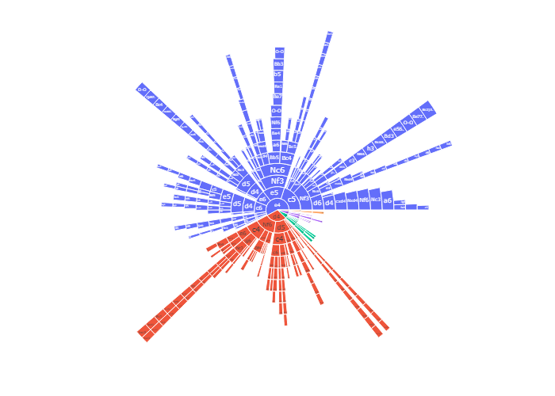

### Awards 🏆

Assorted awards to celebrate the season. See the footnote for more details about each award.[^7]

| Award | Name / Description | Winner(s) | Runner(s)-up |
| --- | --- | --- | --- |
| x | Aces | APJNTU, astralfenix, Der_Bo, drchessdad, jacade, Toonerer |  |
| x | Archbishop of Accuracy | astralfenix | yoitsyeboicat, Ginoux |
| x | Bullet Boss | Sakusen | Fritzmann, rwiedenhoeft |
| x | David Award | drchessdad | APJNTU, Champignon |
| x | Gambit Guru | Toonerer | AndyBarkers, Pophip |
| x | Giri Award | garadas, playlionchess |  |
| x | Grischuk's Cousin | mronemore | Thulp, ShallowJR |
| x | Houdini Award | Whizzz | AACtrl, actuville |
| x | Intimate with Increment | AACtrl | lion88, ShallowJR |
| x | Musing or Snoozing | Champignon | antazhi8, mronemore |

[output cut: 7 more lines]

### Stats - tables 📚

Tons of detailed stats for your reading pleasure. All tables in this section are sortable and searchable - feel free to explore!

#### Best performances / highest accuracy

##### Best relative performances

This table shows players’ *relative* performance ratings – that is, their performance rating over the season minus their initial rating before their first game.[^8] *Includes everyone with a positive relative performance rating over at least five games.*

| # | Player | Games | W | D | L | Initial | Perf | Diff. |
| --- | --- | --- | --- | --- | --- | --- | --- | --- |
| 1 | crouchbag | 10 | 4 | 4 | 2 | 1859 | 2200.9 | 341.9 |
| 2 | drchessdad | 11 | 8 | 1 | 2 | 2138 | 2436.09090909091 | 298.090909090909 |
| 3 | fwcj68 | 7 | 4 | 0 | 3 | 1744 | 2025.85714285714 | 281.857142857143 |
| 4 | MooGroc | 8 | 3 | 1 | 4 | 1679 | 1942 | 263 |
| 5 | JamesMyose | 6 | 3 | 0 | 3 | 1857 | 2114.33333333333 | 257.333333333333 |
| 6 | goirish | 7 | 2 | 3 | 2 | 1746 | 2001.71428571429 | 255.714285714286 |
| 7 | izzie26 | 10 | 4 | 3 | 3 | 1853 | 2097.7 | 244.7 |
| 8 | ABDELKODOUS | 8 | 4 | 1 | 3 | 1858 | 2096.5 | 238.5 |
| 9 | euler24 | 11 | 6 | 2 | 3 | 1909 | 2144.81818181818 | 235.818181818182 |
| 10 | amirkhaled21 | 10 | 5 | 0 | 5 | 1679 | 1910 | 231 |

[output cut: 91 more lines]

##### Lowest ACPL

All players who played at least five games and achieved a season ACPL in the 20th percentile or below. Note that ‘season ACPL’ differs from Lichess game-wide ACPL figures, as it excludes opening moves as well as most moves played in objectively decided positions. See the footnote for full details.[^9] ACPLs based on Lichess’s published figures are provided for comparison purposes.

| Rank | Player | Games | Season ACPL | Lichess ACPL |
| --- | --- | --- | --- | --- |
| 1 | astralfenix | 10 | 30.5806451612903 | 21.5714285714286 |
| 2 | yoitsyeboicat | 5 | 32.8684210526316 | 30.8518518518519 |
| 3 | Ginoux | 11 | 32.9747899159664 | 23.8492871690428 |
| 4 | notzmv | 6 | 33.1855670103093 | 24.9354838709677 |
| 5 | Kjar | 11 | 35.5647058823529 | 24.5477815699659 |
| 6 | jacade | 11 | 38.3492063492063 | 29.6254980079681 |
| 7 | Sakusen | 6 | 39.1032258064516 | 26.8176100628931 |
| 8 | PublixFriedChicken | 9 | 39.7 | 30.0677966101695 |
| 9 | euler24 | 11 | 40.6420233463035 | 31.7072164948454 |
| 10 | lnt | 5 | 40.7 | 27.6158536585366 |

[output cut: 30 more lines]

#### Time spent / strongest opponents

##### Time spent

The 50 players who spent the most clock time over the season.

| Rank | Player | Games | Total time spent |
| --- | --- | --- | --- |
| 1 | Ringelnatz | 11 | 9h 21m 5s |
| 2 | AACtrl | 11 | 9h 0m 24s |
| 3 | Meeklydim | 11 | 9h 0m 7s |
| 4 | y3LL3r | 11 | 8h 51m 30s |
| 5 | Rybkathink | 11 | 8h 43m 43s |
| 6 | KS_Legion_Legionowo | 11 | 8h 42m 12s |
| 7 | Drotciv | 11 | 8h 40m 35s |
| 8 | dave3 | 11 | 8h 35m 55s |
| 9 | asmn | 11 | 8h 31m 8s |
| 10 | drchessdad | 11 | 8h 26m 41s |

[output cut: 40 more lines]

##### Time spent per move (after move 10)

Minimum 3 games played.

| Rank | Player | Games | Moves | Time spent per move | Percentile |
| --- | --- | --- | --- | --- | --- |
| 1 | Snodder | 3 | 61 | 1m 46.0s | 100 |
| 2 | the_breadler | 6 | 117 | 1m 39.4s | 100 |
| 3 | astralfenix | 10 | 215 | 1m 31.7s | 99 |
| 4 | Macastani | 4 | 108 | 1m 27.8s | 99 |
| 5 | Josue_Richard | 8 | 205 | 1m 26.9s | 98 |
| 6 | rodeo | 6 | 148 | 1m 26.1s | 98 |
| 7 | Leasy | 3 | 94 | 1m 25.8s | 97 |
| 8 | Checkers4life | 4 | 82 | 1m 25.3s | 97 |
| 9 | IsaVulpes | 10 | 222 | 1m 24.3s | 96 |
| 10 | dkol | 6 | 104 | 1m 22.7s | 96 |

[output cut: 211 more lines]

##### Strength of schedule

The players who faced the best-scoring opponents over the season, when judged by their collective score over all their *other* games. *Suggested by Tranzoo.*

| # | Player | Opp Games | Opp Pts | Opp % |
| --- | --- | --- | --- | --- |
| 1 | drchessdad | 90 | 65.5 | 72.7777777777778 |
| 2 | APJNTU | 83 | 58 | 69.8795180722892 |
| 3 | Champignon | 75 | 52 | 69.3333333333333 |
| 4 | PawnInertia | 65 | 44.5 | 68.4615384615385 |
| 5 | astralfenix | 70 | 47 | 67.1428571428571 |
| 6 | lnt | 42 | 28 | 66.6666666666667 |
| 7 | arthi15 | 79 | 52.5 | 66.4556962025316 |
| 8 | jessehf | 64 | 42.5 | 66.40625 |
| 9 | rwiedenhoeft | 95 | 62 | 65.2631578947368 |
| 10 | god666 | 86 | 56 | 65.1162790697674 |

[output cut: 68 more lines]

#### Comebacks and upsets

##### Comebacks

The players who achieved the most significant comeback wins and draws over the season.[^10] *Suggested by Lou-E.*

| Rank | Player | CB Games | Wins from < -6 | Wins from < -3 | Draws from < -6 | Draws from < -3 |
| --- | --- | --- | --- | --- | --- | --- |
| 1 | Whizzz | 4 | 3 | 1 | 0 | 0 |
| 2 | AACtrl | 4 | 2 | 2 | 0 | 0 |
| 2 | actuville | 4 | 2 | 2 | 0 | 0 |
| 2 | pavonine | 4 | 2 | 2 | 0 | 0 |
| 3 | no_mind | 5 | 1 | 2 | 1 | 1 |
| 4 | fdar | 3 | 3 | 0 | 0 | 0 |
| 5 | Clarinetref | 4 | 2 | 0 | 1 | 1 |
| 5 | fwg2 | 4 | 2 | 0 | 1 | 1 |
| 6 | book_fan | 3 | 2 | 1 | 0 | 0 |
| 6 | playlionchess | 4 | 1 | 1 | 2 | 0 |

[output cut: 153 more lines]

##### Biggest upsets

Everyone who defeated an opponent who outrated them by at least 100 points.

| Rank | Player | Upset Margin | Link |
| --- | --- | --- | --- |
| 1 | Midnightokar | 285 | https://lichess.org/qGskPq6u |
| 2 | Robert1462 | 284 | https://lichess.org/pbFoE8ua |
| 3 | Neuesamjuan | 272 | https://lichess.org/Hla3gYgy |
| 4 | nerja25390 | 263 | https://lichess.org/kZcKwZwv |
| 5 | MooGroc | 260 | https://lichess.org/XF9kcWQd |
| 6 | ikalel | 258 | https://lichess.org/3JdkJhn8 |
| 7 | Lyrurus | 255 | https://lichess.org/kkS6eais |
| 8 | fwcj68 | 249 | https://lichess.org/xZ3mrgpH |
| 8 | Carlos_Peralta | 249 | https://lichess.org/FCGJaniQ |
| 9 | fdar | 245 | https://lichess.org/XoGX8MDq |

[output cut: 177 more lines]

##### Repeated upsets

Everyone who achieved multiple wins over opponents rated at least 50 points higher.

| Rank | Player | Total Upset Margin | Upsets | Avg Upset Margin | Biggest Margin |
| --- | --- | --- | --- | --- | --- |
| 1 | amirkhaled21 | 964 | 5 | 192.8 | 222 |
| 2 | Lyrurus | 930 | 5 | 186 | 255 |
| 3 | crouchbag | 804 | 4 | 201 | 242 |
| 4 | Rybkathink | 795 | 5 | 159 | 184 |
| 5 | nerja25390 | 750 | 4 | 187.5 | 263 |
| 6 | Neuesamjuan | 644 | 3 | 214.666666666667 | 272 |
| 7 | MooGroc | 623 | 3 | 207.666666666667 | 260 |
| 8 | fwcj68 | 610 | 3 | 203.333333333333 | 249 |
| 9 | Midnightokar | 585 | 3 | 195 | 285 |
| 10 | lucapette | 557 | 4 | 139.25 | 175 |

[output cut: 45 more lines]

#### Dawdlers and instant movers

##### Least time left after move 10

Players who had the least time left after only 10 moves…but still managed to win! *Suggested by Silkthewanderer.*

| Rank | Player | Time left after 10 moves | Link |
| --- | --- | --- | --- |
| 1 | mronemore | 3m 7s | https://lichess.org/IeBCWwAv#19 |
| 2 | Thulp | 8m 48s | https://lichess.org/FXTvxfmI#20 |
| 3 | ShallowJR | 9m 45s | https://lichess.org/7OKFUivi#20 |
| 4 | Traxxin | 11m 35s | https://lichess.org/r2Avpnwd#20 |
| 5 | Silkthewanderer | 12m 33s | https://lichess.org/6DbIX24r#20 |
| 6 | KS_Legion_Legionowo | 12m 51s | https://lichess.org/F9bxXBo7#20 |
| 7 | fhunfi | 13m 30s | https://lichess.org/XkzznMw7#20 |
| 8 | antazhi8 | 13m 31s | https://lichess.org/j5sSzVyi#19 |
| 9 | Thulp | 13m 45s | https://lichess.org/g9yE05w4#19 |
| 10 | applebub | 13m 46s | https://lichess.org/65n5jAGh#19 |

##### Instant moves

Players who made at least five ‘instant’ moves (in under 0.5s), including pre-moves.

| Rank | Player | Instant moves |
| --- | --- | --- |
| 1 | Sakusen | 27 |
| 2 | Fritzmann | 25 |
| 2 | rwiedenhoeft | 25 |
| 3 | jaybir | 24 |
| 3 | SaitamaChecks | 24 |
| 4 | ChiefJab | 22 |
| 4 | Traxxin | 22 |
| 5 | muccino | 21 |
| 6 | adande1 | 20 |
| 6 | arthi15 | 20 |

[output cut: 82 more lines]

#### Longest thinks, time trouble addicts, and lucky escapes

##### Longest thinks

The longest times spent on a single move.

*Top 100 shown.*

| # | Player | Time spent | Colour | Move | Link |
| --- | --- | --- | --- | --- | --- |
| 1 | Champignon | 22m 24s | White | 14 | https://lichess.org/CumwOFuX#27 |
| 2 | antazhi8 | 21m 10s | Black | 9 | https://lichess.org/3VtaXmoL#18 |
| 3 | mronemore | 17m 40s | White | 8 | https://lichess.org/IeBCWwAv#15 |
| 4 | FelixMonterrey | 17m 30s | White | 30 | https://lichess.org/YPYLphbI#59 |
| 5 | drchessdad | 14m 40s | White | 11 | https://lichess.org/Cjo68Fp1#21 |
| 6 | applebub | 14m 35s | White | 8 | https://lichess.org/65n5jAGh#15 |
| 7 | adrienb96 | 14m 31s | Black | 18 | https://lichess.org/RareXySQ#36 |
| 8 | Silkthewanderer | 14m 26s | White | 10 | https://lichess.org/FcG8p9Ly#19 |
| 9 | nouvato | 14m 21s | Black | 15 | https://lichess.org/88e3rgkd#30 |
| 10 | lnt | 14m 18s | White | 25 | https://lichess.org/46On1dkM#49 |

[output cut: 90 more lines]

##### Time trouble addicts

Shows players by proportion of moves made in time trouble (defined as having less than a minute remaining on the clock). Includes everyone who played at least 100 moves over the season while making at least one move in time trouble.

| # | Player | All moves | With < 1min left | Time Trouble % |
| --- | --- | --- | --- | --- |
| 1 | AACtrl | 457 | 205 | 0.448577680525164 |
| 2 | lion88 | 425 | 143 | 0.336470588235294 |
| 3 | ShallowJR | 346 | 115 | 0.332369942196532 |
| 4 | mronemore | 238 | 70 | 0.294117647058824 |
| 5 | rahimftd | 378 | 100 | 0.264550264550265 |
| 6 | antazhi8 | 385 | 100 | 0.25974025974026 |
| 7 | dave3 | 543 | 139 | 0.255985267034991 |
| 8 | KS_Legion_Legionowo | 459 | 111 | 0.241830065359477 |
| 9 | kornuty | 310 | 70 | 0.225806451612903 |
| 10 | fhunfi | 383 | 84 | 0.219321148825065 |

[output cut: 140 more lines]

##### Saved by the bell

Players who made moves with under 5 seconds left on their clock…and still won![^11]

| Player | Moves with under 5s left | Least time left | Link |
| --- | --- | --- | --- |
| lion88 | 11 | 1 | https://lichess.org/NQqmeeqH |
| ShallowJR | 8 | 1 | https://lichess.org/7OKFUivi |
| y3LL3r | 6 | 0 | https://lichess.org/eVVsKUbn |
| NeZnaSahDigra | 5 | 1 | https://lichess.org/vDKC2sjX |
| AACtrl | 5 | 1 | https://lichess.org/knwJXAyf |
| mronemore | 4 | 3 | https://lichess.org/IeBCWwAv |
| AACtrl | 4 | 4 | https://lichess.org/IHwc70hJ |
| Toonerer | 3 | 2 | https://lichess.org/5pNuOnYC |
| AACtrl | 3 | 2 | https://lichess.org/x1g0Mmdm |
| fwcj68 | 3 | 3 | https://lichess.org/toT66Bcu |

[output cut: 14 more lines]

### About

- This report was compiled on 07 March 2022.
- These statistics are presented for general interest only. They are not guaranteed to be comprehensive, complete[^12], accurate, or up to date. They may be periodically revised to incorporate updates and bugfixes.
- Any player determined by Lichess to have violated their Terms of Service when this report was compiled should not appear in the detailed statistics.[^13]
- [Homepage](https://rahulan-c.github.io/lichess4545-stats/) / [source code](https://github.com/rahulan-c/lichess4545-stats)
- Acknowledgements: [Noun Project](https://thenounproject.com/) for the award icons; [Simon Ilincev](https://simonilincev.com/) for chess_graph, which produces the openings sunburst plots.
[^1]: There are several reasons why a pairing might not end up being played, including scheduling difficulties, a lack of available replacements, or one of the players not showing up at the start time!
[^2]: The number of games played in this statistic can differ from the number of games played in the season, as it excludes games where the result of the pairing was later changed to a forfeit win or loss.
[^3]: “Plus” score = played wins - played losses. Also, these season scores exclude any unplayed games, forfeit results or byes.
[^4]: A game’s total clock time is the sum of both players’ move times from move 2 onwards.
[^5]: For these statistics, a played opening line is termed a gambit if it arises from an opening or variation that’s commonly associated with one side sacrificing some material in the opening (in return for compensation) *and* the side that played the gambit actually sacrificed material in the game (for at least 5 consecutive half-moves before move 16). In particular, the list of gambit openings isn’t restricted to named gambits; it also includes for example the Marshall Attack in the Ruy Lopez, the Budapest Defence, and several variations of the Two Knights Defence in the Italian Game. However, this approach excludes games where a side decides to gambit material when *not* playing a traditionally gambit-associated opening. Yes, those should be considered gambits. But they’re not here.
[^6]: Qualifying “gambiteers” are ordered by number of gambit games played before percentage score.
[^7]: *Archbishop of Accuracy*: this is for the player with the lowest average centipawn loss (CPL) over all games. Note that this calculation isn’t based on Lichess’s ACPL figures. It excludes moves played in the first 10 moves of a game and moves with a centipawn loss < 150 in *decided* positions. These are considered to be positions with an evaluation greater than or equal to +300 centipawns for one side. All evaluation data is sourced from Lichess server analysis. To be eligible, players must have played at least five games in the season. *David Award*: the player whose opponents achieved the highest percentage score across the season, excluding games against the player. To be eligible, a player must have played at least 5 games over the season, and their opponents must have collectively played at least 30 games against others. Suggested by Tranzoo. *Egalitarian Award*: intended for the team whose players performed most similarly to each other. First, I compute all players’ *relative* performance ratings – the difference between their actual performance rating (using FIDE’s method) and their initial rating. Then I group all players by team, and give the award to the team with the lowest standard deviation across its players’ relative ratings. Suggested by Silkthewanderer. *Gambit Guru*: most gambits played while scoring above 50%. *MVP Award*: minimum 5 games played. *Rookie Award*: minimum 4 games played. *Saved by the Bell*: Excludes moves made in positions with an evaluation of under +300 centipawns from the mover’s perspective. Ordering is determined first by # moves played with under 5 seconds remaining, then by least time remaining in such conditions, then by worst eval faced. *Slingshot Specialist*: the player with the highest total rating gap between their opponents and themselves when only considering wins against opponents rated at least 50 rating points higher.︎
[^8]: The season performance ratings presented in this report may differ slightly from ratings published on the Lichess4545 website, but both calculations are based on FIDE’s preferred method, and both exclude unplayed games such as forfeit wins/losses and scheduling draws.
[^9]: Season ACPL here excludes the first 10 moves of a game, all zero-CPL moves played in zero-evaluation positions, and moves played in positions where one side has an advantage of +300 centipawns or greater *that aren’t mistakes or blunders*.
[^10]: I award “comeback points” for each game that a player won after their opponent had an advantage of at least 300 centipawns, according to Lichess’ server analysis. The scoring is rather simple. A win after suffering an evaluation disadvantage of more than 6 pawns earns 1 point. A win after being down by 3-6 pawns earns 0.7 points. A draw after being down more than 6 pawns earns 0.5 points. A draw after being down 3-6 pawns earns 0.3 points. Then the points are added up.
[^11]: Excludes moves made in positions where the mover had an objective advantage of +3 or greater. Players are first ordered by number of moves made with 5 or fewer seconds remaining, then by least time they had left (across all qualifying moves), and finally by the worst objective evaluation they faced (again across all moves).
[^12]: For example, this report excludes from its analysis all games of less than 5 plies (half-moves), games that ended in a disconnection or by “cheat detected”, games that were aborted, and games that started from a custom position.
[^13]: However, players who were banned from the Lichess4545 leagues after finishing a season in the top three places are still shown with a podium place in that season’s report.